# One way ANOVA

Let us consider the PlantGrowth data set in R. This contains results from an experiment to compare yields (as measured by dried weight of plants) obtained under a control and two different treatment conditions.

Do either of the treatments make any difference to yield?

A general prediction could be that there are differences among the mean yields of each of the three groups, while a suitable null hypothesis could be that there is no difference among the three groups.

### 0.0.1 Load the data into R

We first load the data into R, then copy it a data frame called `df` and inspect it.

```r
data(PlantGrowth)
df <- data.frame(PlantGrowth)
str(df)
```

```
'data.frame':   30 obs. of  2 variables:
 $ weight: num  4.17 5.58 5.18 6.11 4.5 4.61 5.17 4.53 5.33 5.14 ...
 $ group : Factor w/ 3 levels "ctrl","trt1",..: 1 1 1 1 1 1 1 1 1 1 ...
```

We have two columns of data. The response variable is *weight*, which is a numeric variable, while the predictor is *group* which is a nominal variable. R calls such variables *factors*, and in R-speak, we have in this case 3 *levels* - control, treatment 1 and treatment 2.

### 0.0.2 Conditions required for an ANOVA

The data should be:

- normally distributed
- the groups should have equal variances

#### 0.0.2.1 Box plot

We check this first with a box plot

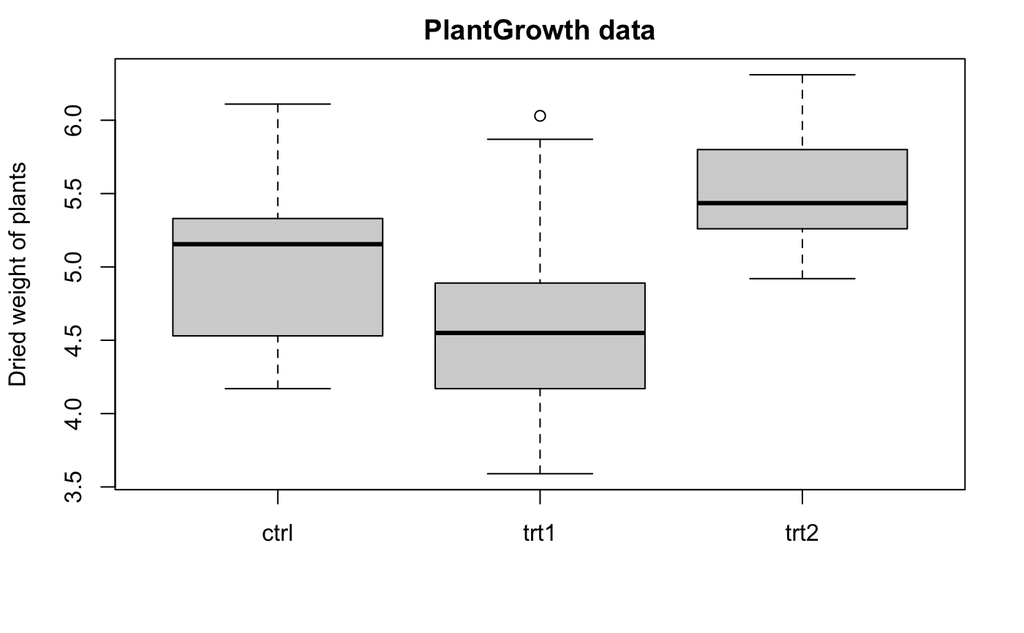

```r
boxplot(weight ~ group, data = df, main = "PlantGrowth data",
        ylab = "Dried weight of plants", col = "lightgray", varwidth = TRUE)
```

from which it seems that the values in each data set are more or less symmetrically distributed.

#### 0.0.2.2 Are the residuals of the data normally distributed?

We can carry out a Shapiro-Wilks test for normality on the residuals of each group to check this

```r
residuals <- as.vector(sapply(split(df$weight,df$group),function(group,group_mean){group-mean(group)}))
shapiro.test(residuals)
```

```
    Shapiro-Wilk normality test

data:  residuals
W = 0.96607, p-value = 0.4379
```

The null hypothesis of this test is that the residuals are normally distributed. Since the p-value here is much greater than 0.05, these data give us no grounds to reject this.

#### 0.0.2.3 Do the groups have equal variance

We can carry out a Fligner test to check for this

```r
fligner.test(weight~group,data=df)
```

```
    Fligner-Killeen test of homogeneity of variances

data:  weight by group
Fligner-Killeen:med chi-squared = 2.3499, df = 2, p-value = 0.3088
```

The null hypothesis of this test is that the groups have equal variance. Since the p-value here is much greater than 0.05, these data give us no grounds to reject this.

Thus the conditions for carrying out an ANOVA are met.

First we will calculate the F-statistic and p-value manually, to check that we understand where they come from, then we will get them directly using the built-in `anova()` or `aov()` commands. These are what you would normally use when carrying out an ANOVA.

### 0.0.3 Manual calculation of the F statistic and p-value (skip this bit if you want to)

#### 0.0.3.1 Degrees of freedom

```r
N <- nrow(df)
K <- length(unique(df$group))
d1 <- K-1
d2 <- N-K
```

#### 0.0.3.2 Between-group variability

```r
overall_mean <- mean(df$weight)
group_counts<-sapply(split(df$weight,df$group),length)
group_means<-sapply(split(df$weight,df$group),mean)
bgv <- sum((group_counts*(group_means-overall_mean)^2)/d1)
bgv
```

```
[1] 1.88317
```

#### 0.0.3.3 Within-group variability

```r
wgv <- sum(sapply(split(df$weight,df$group),function(d,m){sum((d-mean(d))^2)}))/d2
wgv
```

```
[1] 0.3885959
```

#### 0.0.3.4 F-statistic

```r
F <- bgv/wgv
F
```

```
[1] 4.846088
```

#### 0.0.3.5 p-value

```r
pval <- pf(F,d1,d2,lower.tail=FALSE)
pval
```

```
[1] 0.01590996
```

### 0.0.4 Using built in commands - the simpler way!

We could instead use the built-in `anova()` or `aov()` functions in R. This is much simpler!

```r
anova(lm(weight~group,data=df))
```

```
Analysis of Variance Table

Response: weight
          Df  Sum Sq Mean Sq F value  Pr(>F)
group      2  3.7663  1.8832  4.8461 0.01591 *
Residuals 27 10.4921  0.3886
---
Signif. codes:  0 ‘***’ 0.001 ‘**’ 0.01 ‘*’ 0.05 ‘.’ 0.1 ‘ ’ 1
```

```r
summary(aov(weight~group,data=df))
```

```
            Df Sum Sq Mean Sq F value Pr(>F)
group        2  3.766  1.8832   4.846 0.0159 *
Residuals   27 10.492  0.3886
---
Signif. codes:  0 ‘***’ 0.001 ‘**’ 0.01 ‘*’ 0.05 ‘.’ 0.1 ‘ ’ 1
```

The p-value is 0.016, so there is good evidence that the treatments do affect the rate of plant growth.

We could report this result as (F=4.85, d.f=2,27,p<0.05)

### 0.0.5 Post-hoc comparisons

Which groups are different?

```r
TukeyHSD(aov(weight~group,data=df))
```

```
  Tukey multiple comparisons of means
    95% family-wise confidence level

Fit: aov(formula = weight ~ group, data = df)

$group
            diff        lwr       upr     p adj
trt1-ctrl -0.371 -1.0622161 0.3202161 0.3908711
trt2-ctrl  0.494 -0.1972161 1.1852161 0.1979960
trt2-trt1  0.865  0.1737839 1.5562161 0.0120064
```

this shows that only one of the differences in growth rates is significant: treatment 2 is significantly better than treatment 1. The p-values here have been adjusted (a Bonferoni correction?) to account for the danger, that, when making multiple pair-wise comparisons, the type 1 error rate can increase.

Does the box plot confirm this conclusion?